# My fantastic R markdown

This is the cool subtitle of my document

Misi & Viki

28 September 2022

# Write with Markdown

You can easily include text to a markdown file. With two spaces  
you can start a new paragraph.

When you include a backslash  
you will have a new line.

You can also play around with the text you include. You can create **bold** or *italic* parts or could even strikethrough some words. You may need to include some superscrips x<sup>2</sup> or subsripts x<sub>1</sub>.

# Headers

When creating documents you will most probably need to use some headings.

# Lists

You can include cool ordered and unordered lists as well.

**Thing I like the most**

- Coding
- R
- The R Mentoring Class
  - Misi
  - Viki

*My aims for the year*

1. Become a pro in coding
2. Attend all R Mentoring classes
3. Enjoy my studies

# Links

When you would like to put a link in your document, you can put the whole thing in the document, or you can also link it to a word which looks much better.

Here is a cool website to style my markdowns. https://prettydoc.statr.me/

Here is a cool [website](https://prettydoc.statr.me/) to style my markdowns.

# Equations

During your studies you will probably need to include some equations as well.

You can do this within your text. $e^{i \pi} + 1 = 0$ And continue explaining.

Or you may create a separate block.

$$E = mc^{2}$$

# Chunk options

After text elements the other most important thing you will put into your markdown is code.

There are several different options you can use within the {}. Without anything the code you write will be shown and the results as well.

```r
df = iris
head(df, 3)
```

```
##   Sepal.Length Sepal.Width Petal.Length Petal.Width Species
## 1          5.1         3.5          1.4         0.2  setosa
## 2          4.9         3.0          1.4         0.2  setosa
## 3          4.7         3.2          1.3         0.2  setosa
```

With `eval=FALSE` (or `eval=F`) the code won’t be evaluated, but it will be printed out.

```r
df = iris
head(df, 3)
```

With `echo=F` you can only show the output of the chunk but hide the code you used to get it. This is mostly used for figures.

```
##   Sepal.Length Sepal.Width Petal.Length Petal.Width Species
## 1          5.1         3.5          1.4         0.2  setosa
## 2          4.9         3.0          1.4         0.2  setosa
## 3          4.7         3.2          1.3         0.2  setosa
```

With `include=F` you can exclude the chunk. It will run in the background. This is useful for data import or package loadings.

# Figures

Here is the code for generating the plot

```r
library(ggplot2)

p <- ggplot(data=iris,mapping=aes(x=Petal.Length,y=Petal.Width))+
  geom_point(aes(color=Sepal.Width))+
  geom_smooth(method="lm")+
  scale_color_viridis_c()+
  scale_x_continuous(breaks=1:8)+
  labs(title="This Is A Title",subtitle="This is a subtitle",x=" Petal Length",
       y="Petal Width", caption="This is a little caption.")+
  facet_wrap(~Species)+
  theme_bw()+
  theme(
    axis.title=element_text(color="cyan4",face="bold", size = 11),
    plot.title=element_text(color="cyan4",face="bold", size = 18),
    plot.subtitle=element_text(color="cyan4", face = "italic", size = 14),
    panel.grid=element_blank(),
    legend.position = "none"
  )

show(p)
```

[output not shown]

With `message=F` you can also hide any additional messages. (*for example*: ‘geom_smooth()’ using formula ‘y ~ x’)

Or can change the size by the lines `out.width=` command. After the equal sign you can use percentages like *“50%”* or pixel sizes like *“300px”*

**Or by defining the height and width of the figure**

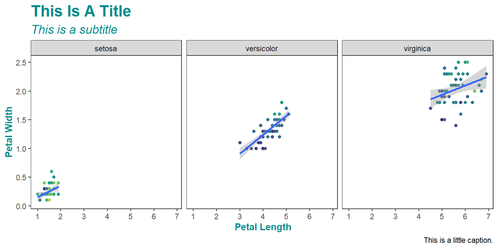

# Tables

There are some extra option to show your data in a markdown. The package I used the most was [KableExtra](https://cran.r-project.org/web/packages/kableExtra/vignettes/awesome_table_in_html.html).

This is what the basic table would look like.

```r
head(df, 3)
```

```
##   Sepal.Length Sepal.Width Petal.Length Petal.Width Species
## 1          5.1         3.5          1.4         0.2  setosa
## 2          4.9         3.0          1.4         0.2  setosa
## 3          4.7         3.2          1.3         0.2  setosa
```

This is how it looks with kableExtra.

```r
library(kableExtra)

head(df, 3) %>%
  kbl()
```

| Sepal.Length | Sepal.Width | Petal.Length | Petal.Width | Species |
| --- | --- | --- | --- | --- |
| 5.1 | 3.5 | 1.4 | 0.2 | setosa |
| 4.9 | 3.0 | 1.4 | 0.2 | setosa |
| 4.7 | 3.2 | 1.3 | 0.2 | setosa |

You can add different styles.

```r
head(df, 3) %>%
  kbl() %>%
  kable_classic(full_width = F)
```

| Sepal.Length | Sepal.Width | Petal.Length | Petal.Width | Species |
| --- | --- | --- | --- | --- |
| 5.1 | 3.5 | 1.4 | 0.2 | setosa |
| 4.9 | 3.0 | 1.4 | 0.2 | setosa |
| 4.7 | 3.2 | 1.3 | 0.2 | setosa |

Or even some interactive features like hovering.

```r
head(df, 3) %>%
  kbl() %>%
  kable_paper(c("striped", "hover"), full_width = F)
```

| Sepal.Length | Sepal.Width | Petal.Length | Petal.Width | Species |
| --- | --- | --- | --- | --- |
| 5.1 | 3.5 | 1.4 | 0.2 | setosa |
| 4.9 | 3.0 | 1.4 | 0.2 | setosa |
| 4.7 | 3.2 | 1.3 | 0.2 | setosa |

There are some additional packages you can use to format your tables nicely.

- **flextable**
- **gt**
- **kable**

# Styles

To add some extra flavor to your docs you can use different themes. For this the easiest is to use [Bootswatch](https://bootswatch.com/). To change the styles you just need to replace *“flatly”* in the header to one of the names you can see on the website.

Another way is to use [Prettydoc](https://prettydoc.statr.me/). For this you can check their website and see how this works.